# Advanced Programming

Árpád Tamási · ELTE Faculty of Social Sciences

Session 7 — 20 October 2026

## Today

**60 minutes active, 30 minutes consultation.**

Halftime · Ideas · Two weeks on your project · gstack · Impeccable · Homework

# Halftime

## Halftime

Half the semester is behind us. Your projects are different sizes, and they are in different places.

**Some of you are done.** Then make it bigger.

**Some of you aren’t.** Then use the time to get there.

## If you’re done: make it bigger

1. **If you built something you really use,** you already know what’s missing. Build that.
2. **If you don’t use it yet,** ask yourself: what would it take for me to use it? Build that.
3. **If you would never use it,** find someone who would, and ask them what is missing. Or ask gstack: `/office-hours`.

## Your project is the homework now

**For the rest of the semester, the homework is your project moving forward.** Use the time: six weeks to the first demos.

[figure not shown]

# Ideas

## Ideas

**A database · users and login · a real interface · connecting it to AI · and more**

Any of these, or something else. A few words on each.

## A database

#### What it’s for

- Data that outlives one run of your program.
- Several people, or several devices, using the same data.
- Finding things fast in a lot of data.
- Changes that must not half-happen: a payment, a booking.

#### What it adds

- A schema to design, and migrations when it changes.
- Somewhere for it to run: a server or a service, with a cost or a free-tier limit.
- Backups.
- Who may read and write it, and its keys kept out of git.

## Four kinds of database

|  | Relational (SQL) | NoSQL: document | NoSQL: key–value | Vector store |
| --- | --- | --- | --- | --- |
| **Data** | tables with fixed columns, rows linked by keys | documents like JSON, fields can differ | one value for each key | vectors: numbers that stand for the meaning of a text or an image |
| **Query** | SQL, joining tables | by the fields of a document | only by the key | by similarity: “the closest ones to this” |
| **Examples** | SQLite (one file), PostgreSQL | MongoDB, Firestore | Redis, the browser’s `localStorage` | pgvector (in PostgreSQL), Chroma |
| **Fits** | clear structure, things that relate | changing shape, data synced to an app | settings, sessions, caches | search by meaning; giving a language model the right documents |

## Users and login

#### What it’s for

- Each person sees their own data.
- Knowing who did what: who added it, who changed it.
- Different people may do different things: someone edits, someone only looks.

#### What it adds

- Accounts: signing up, a forgotten password, deleting an account.
- Personal data: from now on you store who your users are.
- Every screen and every request checks who is asking, and what they may do.
- A test account ready for the demo.

## Two ways to log in

|  | Username and password | OAuth: “Sign in with GitHub / Google” |
| --- | --- | --- |
| **Who checks the password** | you | the provider |
| **What you store** | a hash of the password, never the password | an ID from the provider |
| **A secret you now hold** | your users’ passwords: a leak hurts them wherever they reused it | only your app’s own key |
| **Your work** | hashing, password reset, lockout | register your app, handle the redirect |

OWASP Password Storage Cheat Sheet: passwords “should never be stored in plain text”; Argon2id first. OAuth 2.0: RFC 6749, 2012.

## A real interface

#### What it’s for

- The audience sees only the screen. It should look finished.
- It works on a phone: the audience scores on their phone.
- Several screens and a path through them, instead of one page or a terminal.

#### What it adds

- Another language and toolchain: JavaScript, packages, a build step.
- The screen and the logic split apart, often with an API between them.
- Design decisions: layout, wording, what an empty or failed screen shows.
- For a phone app: an app store account and a review, which take time.

## Three ways to build it

|  | In its own words | Fits |
| --- | --- | --- |
| **React** | “a JavaScript library for rendering user interfaces” | interactive apps with many screens |
| **Astro** | “The web framework for content-driven websites”, “Zero JavaScript, by default” | sites, reports, portfolios |
| **React Native** | “brings the best parts of developing with React to native development” | phone apps, iOS and Android |

react.dev, astro.build, reactnative.dev (October 2026).

## Connect it to AI: MCP

#### What it’s for

- Your program becomes something an AI assistant can use: Claude, ChatGPT, Cursor, VS Code.
- Your data and your functions, through a chat: *“What did I spend on food in October?”*

#### What it adds

- Each function described as a tool: a name, its inputs, what it returns.
- A server, on your machine or online.
- Whatever you expose, the AI can call. Expose only what is safe.

“MCP (Model Context Protocol) is an open-source standard for connecting AI applications to external systems.” modelcontextprotocol.io, October 2026.

## And more

| Idea | What it gives | What it adds |
| --- | --- | --- |
| **Put it online** | anyone can try it on their own phone | hosting; free tiers that sleep or expire |
| **A language model inside** | summarise, classify, answer in plain words | a cost per call, an API key, user data leaving the machine |
| **Export and share** | a PDF, a CSV, a link someone can open | formats, and who can see the link |
| **Run on a schedule** | fresh data every day or every week | a scheduler such as GitHub Actions; failures nobody sees |
| **Your own API** | other programs can use yours | keys, limits, and not breaking the people who rely on it |
| **Real or bigger data** | real numbers, real surprises | cleaning, licences, and possibly personal data |

## For games: a player that plays itself

#### What it’s for

- A computer opponent that makes real decisions.
- A bot that tests your game by playing it, over and over.
- Each turn: the game state and the legal moves go in, one move comes out.

#### What it adds

- A decision model such as **Jev**: it writes no text, it picks one of the options you give it.
- An API key, and a cost for every move.
- A correct list of legal moves: the model only chooses from what you offer.
- A fallback move when the network fails.

Jev, TypeSafe AI, released 15 September 2026: answers with one of up to 255 options, a level, or yes/no with a probability (aimlapi.com model page; Towards AI, “What is Jev”). Check access and price before you build on it.

# Two weeks on your project

## Two weeks

No class until 10 November. It looks like a lot of time. It isn’t: use it.

**Decide what you still want to build.** Pick something big enough that you might need my help.

**Write the plan before you start.** Your spec is the plan: a change with OpenSpec *propose*, and its `tasks.md` is the list. What you tick off is your progress.

## Keep the demo working

**First a thin path from the input to the screen, end to end.** Then the details.

**After every change, walk through your demo.** `main` is never broken: changes go on a branch.

“Walking skeleton”: Alistair Cockburn. “Tracer bullets”: Andrew Hunt and David Thomas, *The Pragmatic Programmer*, 1999.

## Track where you are

**One push a day, one line in your log.**

**Once a week, compare with the plan.** If you’re behind, cut: *must · should · could · won’t*. You cut from *could*.

[figure not shown]

MoSCoW prioritisation: Dai Clegg, 1994, part of the DSDM method.

## If you get stuck

# gstack

## Y Combinator

Since 2005, it has invested in very young startups: today **$500k per company**. Airbnb, Stripe and Dropbox started there.

At YC, **office hours** are when a partner sits down with the founders and asks the hard questions about their product.

ycombinator.com/about (October 2026); founders: Paul Graham, Jessica Livingston, Trevor Blackwell, Robert Morris. Airbnb, Dropbox, Stripe as YC companies: TechCrunch, 16 July 2014.

## gstack

**By Garry Tan, President and CEO of Y Combinator.** Open source, MIT licence, free. *“It turns Claude Code into a virtual engineering team.”*

[figure not shown]

github.com/garrytan/gstack, README (version 1.91, October 2026): “The sprint”.

## Which command, when

| If this is your problem | Try |
| --- | --- |
| “I’m not sure this is worth building.” | `/office-hours` |
| “My plan is too big for the time I have.” | `/plan-ceo-review`, *Reduction* mode |
| “It runs, but is it right?” | `/review` |
| “Does my demo still work after the last change?” | `/qa` |
| “Something broke, and I don’t know why.” | `/investigate` |

## Installing gstack

**Open Claude Code and say:**

> *Install gstack from github.com/garrytan/gstack, following its README.*

The README’s own words: “paste this. Claude does the rest.”

**What it needs:** Git and Bun (on Windows also Node.js). Setup builds its tools and downloads a browser for `/qa`. **Telemetry is off unless you say yes;** it asks once.

github.com/garrytan/gstack, README: Install, Privacy & Telemetry.

# Impeccable

## Impeccable

**By Paul Bakaus.** Open source, Apache 2.0 licence.

**A design skill for your coding agent:** Claude Code, Codex, Cursor, Gemini CLI, GitHub Copilot and others.

**The audience scores whether they get it.** What they see on the screen is all they have.

**It works on your demo slides too,** if you make them in HTML.

impeccable.style; the skill’s own SKILL.md (version 4.6).

## Same request, first pass

[figure not shown]

**Without Impeccable**

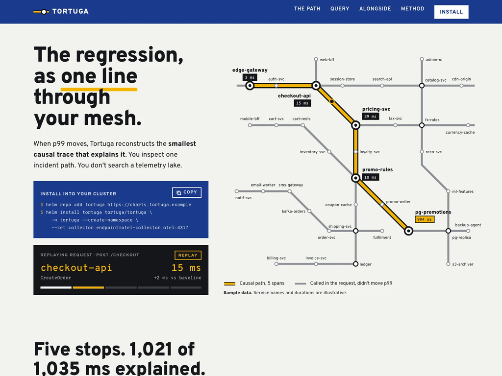

**With Impeccable**

impeccable.style/gallery, “Observability”: “First-pass results, before manual polish.”

## Which command, when

| If this is your problem | Try |
| --- | --- |
| “Something looks off, and I can’t say what.” | `critique` |
| “It looks wrong on a phone.” | `adapt` |
| “People don’t get the labels or the error messages.” | `clarify` |
| “It breaks on empty or strange input.” | `harden` |
| “Can everyone use it, and is it fast enough?” | `audit` |
| “I’d like to see a few versions before I choose.” | `generate` |
| “It works, but nobody will remember it.” | `delight` |
| “It works. Now it should look finished.” | `polish` |

## Installing Impeccable

**Open Claude Code and say:**

> *Install Impeccable from impeccable.style.*

It works with Codex, Cursor, Gemini CLI and GitHub Copilot as well.

impeccable.style, Install.

# Homework

## Homework 7 — Your two weeks

1. **What you moved forward.** What works now that did not work two weeks ago? Link the commits: what is not pushed does not exist.
2. **One question.** About your project, your demo, or anything in the course.

Due **Saturday 7 November, 20:00**. Late until Monday 9 November, 20:00, for half credit.

## Homework 8 — Your demo

1. Read section 1 of your README again: *The demo*.
2. If it no longer describes what you want to show, change it with OpenSpec *propose*.
3. Commit and push.
4. Paste the final version on Canvas.

Due **Saturday 7 November, 20:00**. Late until Monday 9 November, 20:00, for half credit.

## The dates

| 27 October, 3 November | no class |
| --- | --- |
| **7 November** | your two weeks, and your demo description |
| 10 November | next class |
| **28 November** | your slides in your repository |
| **1 and 8 December** | demos |